# The built-in application

Muhammad Yaseen

2026-11-09

# 1 Abstract

`bys_app()` opens an application in the web browser that runs the analyses of the package without code: the trial, the earlier trial as prior, the Bayesian AMMI or SREG model, the biplot with HPD regions and a comparison of models. This vignette describes its pages and how it keeps its results reproducible.

# 2 Starting the application

```r
bys_app(
    launch.browser = TRUE
  )
```

The application needs the suggested packages **shiny**, **bslib** and **DT**. **magick** with WebP support is optional: with it the plots are sent to the browser as lossless WebP images, smaller than the same PNG.

```r
isTRUE(tryCatch(requireNamespace("magick", quietly = TRUE) && isTRUE(magick::magick_config()$webp),
                error = function(e) FALSE))
```

```
[1] TRUE
```

`TRUE` means WebP is available; otherwise the application sends PNG images.

# 3 The pages

[output not shown]

Every result page has the same tabs:

- **Interpretation** gives the plain-language reading of `bys_interpret()`, with a button that copies it.
- **Plot** shows the figure, which can be saved as PNG, PDF or WebP.
- **Table** shows the numbers, rounded, in a sortable table with buttons to copy them or save them as CSV or Excel.
- **Output** shows the printed result as text, with a button that copies it.

The model page has a further tab, **R code**, with the code that reproduces the fit outside the application.

The model page after a fit of `cultivo2009` with `cultivo2008` as prior and two terms:

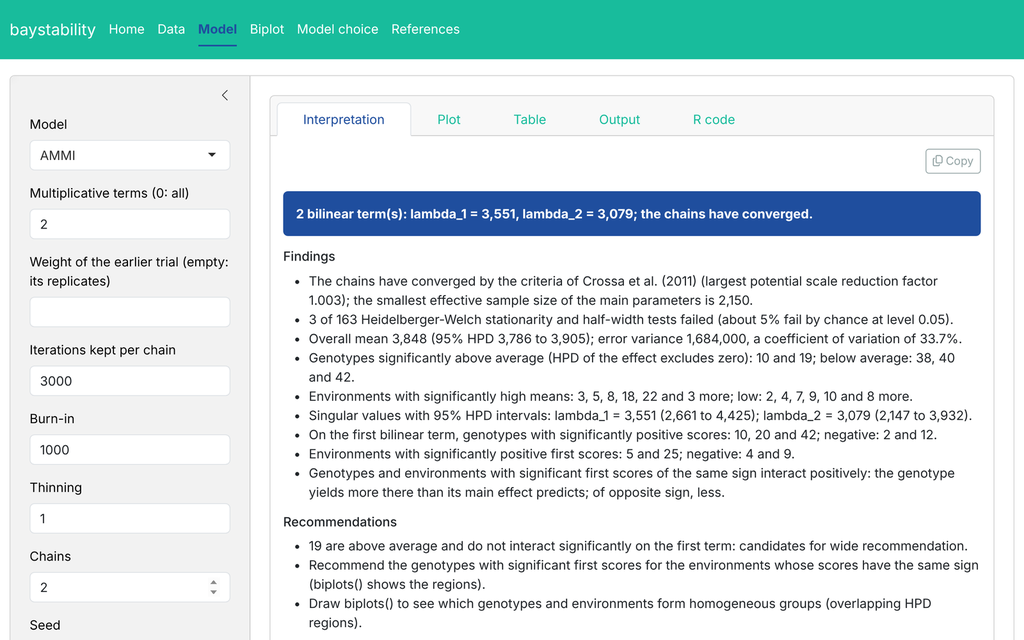

The biplot page of the same fit:

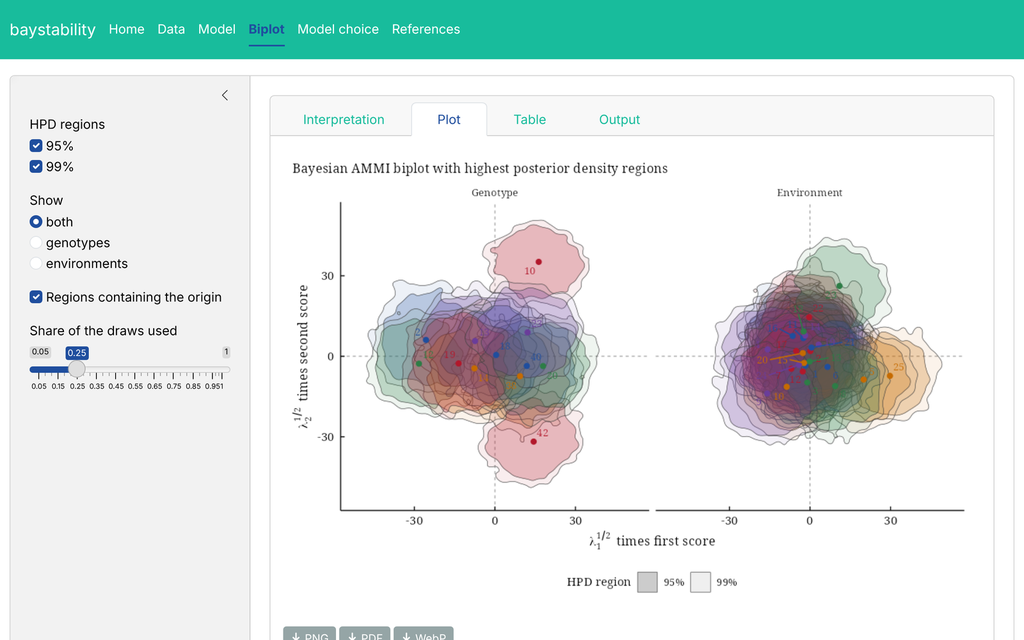

# 4 Reproducibility

For the settings of the screenshots, the R code tab shows:

```r
settings <-
  list(
      .y      = "y"
    , .gen    = "entry"
    , .env    = "site"
    , .rep    = "rep"
    , .nIter  = 3000
    , .n0     = NULL
    , .model  = "AMMI"
    , .k      = 2
    , .burnin = 1000
    , .thin   = 1
    , .chains = 2
    , .priors = bys_priors(
          mu_mean     = 0
        , mu_var      = 1e+8
        , tau_mean    = 0
        , tau_var     = 1e+8
        , delta_mean  = 0
        , delta_var   = 1e+8
        , lambda_mean = 0
        , lambda_var  = 1e+8
        , nu          = 1
        , s2          = NULL
        )
    , .level  = 0.95
    , .seed   = 1
    )
cat(baystability:::.bys_app_code(a = settings, source = "cultivo", prior_source = "cultivo"))
```

```
library(baystability)
data(cultivo2009)
data(cultivo2008)
fit <-
  bayes_ammi(
      .data       = cultivo2009
    , .y          = y
    , .gen        = entry
    , .env        = site
    , .rep        = rep
    , .nIter      = 3000
    , .prior_data = cultivo2008
    , .n0         = NULL
    , .model      = "AMMI"
    , .k          = 2
    , .burnin     = 1000
    , .thin       = 1
    , .chains     = 2
    , .priors     = bys_priors(lambda_var = 1e+08, nu = 1)
    , .level      = 0.95
    , .seed       = 1
    , .align      = TRUE
    , .waic       = TRUE
    )
fit
bys_interpret(
    x             = fit
  , higher_better = TRUE
  , top           = 5
  )
```

The seed fixes the draws, so the code returns the same numbers as the application.

# 5 Deploying

`bys_app_object()` returns the application object without running it, for a server:

```r
# app.R on a Shiny server
baystability::bys_app_object()
```

# 6 References

Perez-Elizalde, S., Jarquin, D. and Crossa, J. (2012). A general Bayesian estimation method of linear-bilinear models applied to plant breeding trials with genotype x environment interaction. *Journal of Agricultural, Biological, and Environmental Statistics*, 17(1), 15–37. doi:10.1007/s13253-011-0063-9